# Hypertension treatment - Clinical Trial Data Analysis and RBM

Tomasz Baczkun

2025-09-17

### Objective

This is the statistical analysis of a Phase III randomized control clinical trial data. The aim is to assess the efficiency of a new hypertension drug - CardioX (Drug A) - against an active comparator (Drug B) and placebo. Additionally, risk base monitoring (RBM) will be conducted.

### Source

The data were synthetically created by the kaggle user Isabella D., and can be found [here](https://www.kaggle.com/datasets/isabelladil/phase-iii-clinical-trial-dataset).

### Data overview

```
## 'data.frame':    1000 obs. of  12 variables:
##  $ subject_id       : int  1 2 3 4 5 6 7 8 9 10 ...
##  $ site_id          : int  49 37 1 25 10 36 18 49 47 24 ...
##  $ age              : int  54 44 58 48 57 59 44 45 40 56 ...
##  $ gender           : Factor w/ 2 levels "Female","Male": 2 2 2 2 1 2 2 1 2 1 ...
##  $ enrollment_date  : Date, format: "2022-01-01" "2022-01-02" ...
##  $ treatment_group  : Factor w/ 3 levels "Drug A","Drug B",..: 1 3 1 2 1 3 1 2 1 1 ...
##  $ adverse_events   : int  0 1 0 0 2 1 3 1 0 3 ...
##  $ dropout          : Factor w/ 2 levels "No","Yes": 1 1 2 1 1 1 2 2 1 1 ...
##  $ systolic_bp      : int  117 111 122 122 105 128 139 141 103 119 ...
##  $ diastolic_bp     : int  74 57 89 85 90 85 120 75 84 93 ...
##  $ cholesterol_level: int  229 173 220 175 185 206 197 172 197 215 ...
##  $ AE_present       : Factor w/ 2 levels "Yes","No": 2 1 2 2 1 1 1 1 2 1 ...
```

#### Overview of the continuous variables:

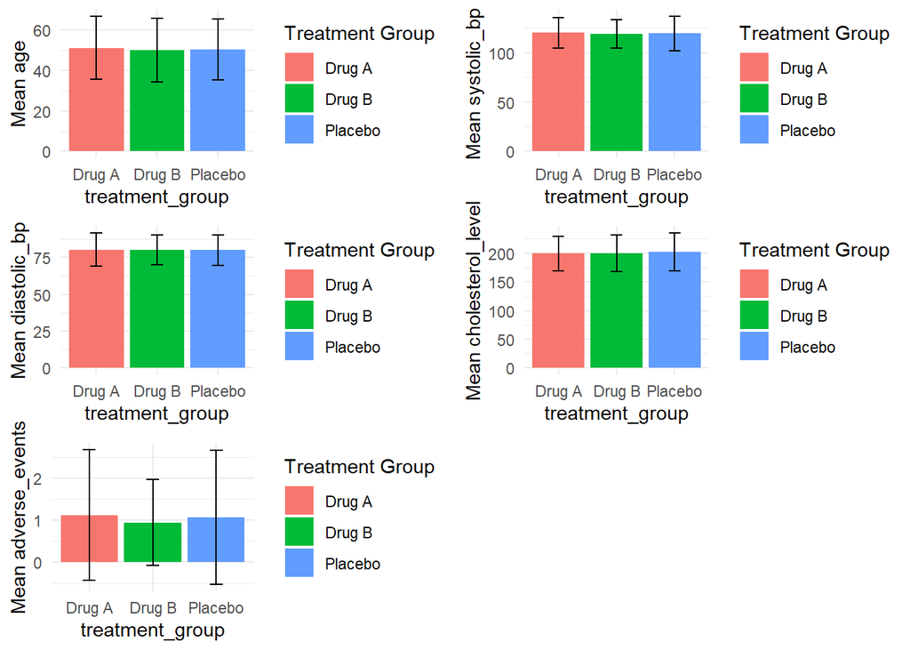

#### Overview of the registration dates:

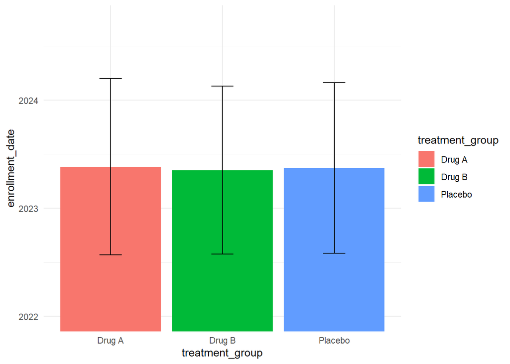

#### Overview of the binary variables:

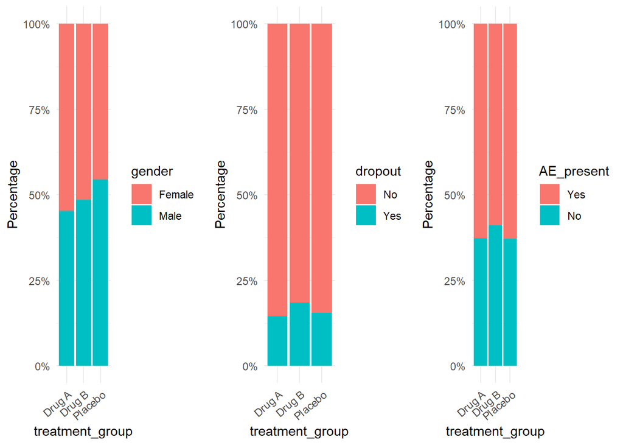

Visual analysis indicates no conclusive differences in between the treatment groups with respect to other variables.

### Efficiency

The efficiency of CordiaX (Drug A) against Drug B and placebo was tested with respect to systolic and diastolic blood pressure, while taking into account cholesterol level, age and gender. As MANOVA analysis was inappropriate due to the violation of the multivariate normality of the residuals assumption (see Appendix A.) PERMANOVA was conducted in its place. The results were as follows:

```
## Permutation test for adonis under reduced model
## Marginal effects of terms
## Permutation: free
## Number of permutations: 1000
##
## adonis2(formula = D ~ treatment_group + cholesterol_level + age + gender, data = df, permutations = 1000, by = "margin", parallel = 20)
##                    Df SumOfSqs      R2      F  Pr(>F)
## treatment_group     2     0.71 0.00036 0.1791 0.94505
## cholesterol_level   1     9.34 0.00468 4.6802 0.01399 *
## age                 1     0.80 0.00040 0.4013 0.63536
## gender              1     3.01 0.00151 1.5074 0.20380
## Residual          994  1984.00 0.99299
## Total             999  1998.00 1.00000
## ---
## Signif. codes:  0 '***' 0.001 '**' 0.01 '*' 0.05 '.' 0.1 ' ' 1
```

(The assumption of homogeneity of multivariate dispersion was met. For the details, see Appendix B.)

No variance in the systolic and diastolic blood pressure was significantly explained by the treatment group. The only significant predictor was the cholesterol, but the variance of systolic and diastolic blood pressure it explained is trivial. Hence, there is no evidence of the superior efficiency of Drug A over Drug B or the placebo.

### RBM

Facilities were investigated with respect to the adverse events, dropouts, systolic and diastolic blood pressure.

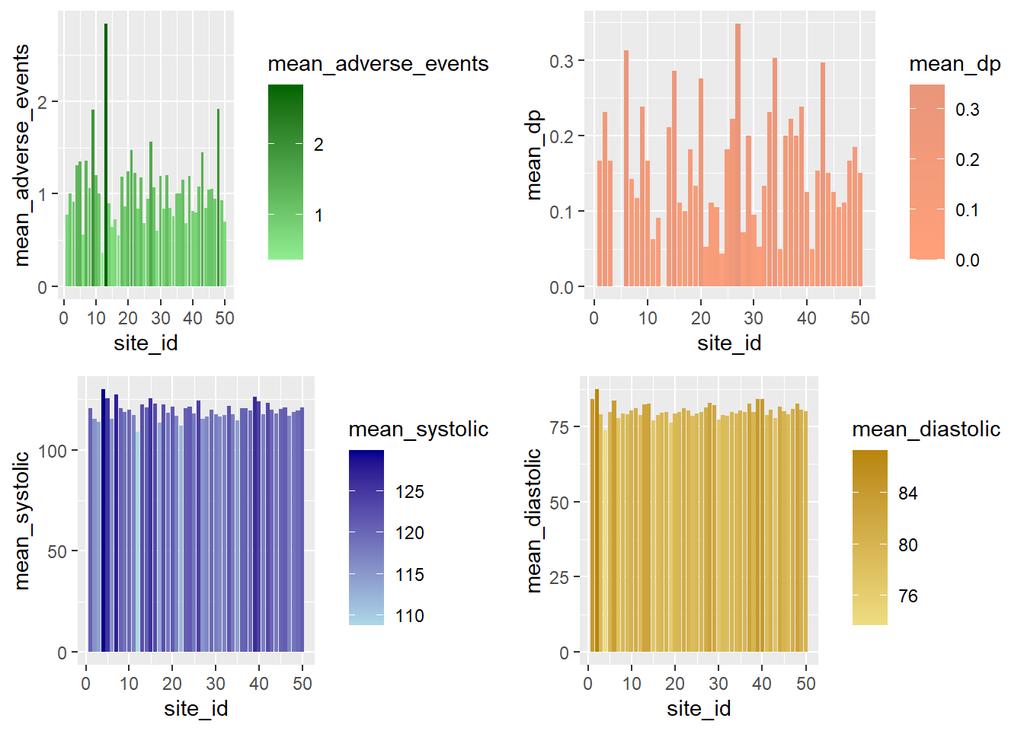

While difference between patients’ systolic and diastolic blood pressure between the facilities is negligible, some sites showed high number of adverse events and dropouts per patients.

IDs of facilities exhibiting high mean of adverse events: 9, 13, 48.

IDs of facilities exhibiting high mean of dropouts: 6, 27, 34.

IDs of other facilities found in top 10 highest scores of both mean adverse events and mean dropouts: 20, 43, 48.

All of the above mentioned facilities are flagged for investigation, with a reccomendation to pay a special attention to facility 48.

### Summary

There is no conclusive evidence that CardioX (Drug A) outperforms Drug B or placebo. Moreover, facilities with alarmingly high level of dropouts and adverse events were identified and flagged for inspection, namely: 6, 9, 13, 20, 27, 34, 43, 48.

#### Appendix A

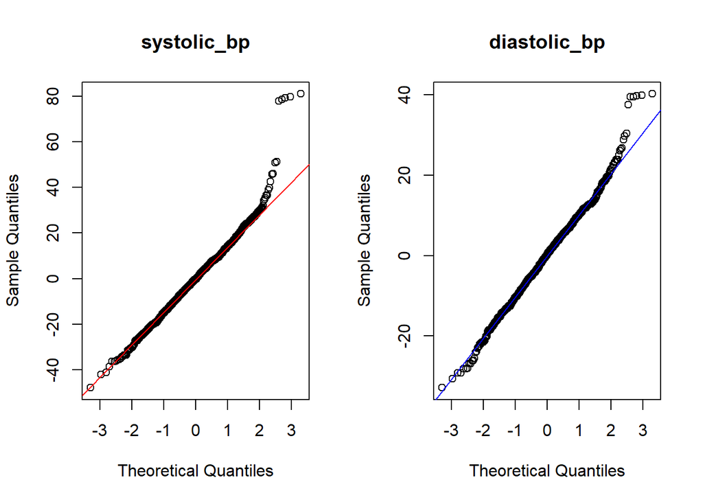

#### Appendix B

```
##
## Permutation test for homogeneity of multivariate dispersions
## Permutation: free
## Number of permutations: 1000
##
## Response: Distances
##            Df Sum Sq Mean Sq      F N.Perm Pr(>F)
## Groups      2   0.90 0.44999 0.9002   1000 0.4246
## Residuals 997 498.36 0.49986
```